# Bayesian classification

# Baseline Naive Bayes

## Bayesian Approach

The **Naive Bayes** estimates $P(\text{emotion} | \text{tokens})$ using Bayes’ formula:

$$P(C_k | X) = \frac{P(X | C_k) \cdot P(C_k)}{P(X)}$$

Where:

- $C_k$ = class (emotion)
- $X$ = features (unigram + bigram tokens)
- $P(C_k)$ = prior (distribution of emotions in the training set, weighted)
- $P(X | C_k)$ = likelihood (probability of features given the emotion)
- $P(X)$ = normalisation (constant)

## Model with Bigrams + Weights

```r
# create unigram + bigram tokens
stopwords_emotion <- setdiff(
    stopwords::stopwords("en"),
    c("not", "no", "very", "so")
)

# Unigram tokens
tokens_uni <- data %>%
    tidytext::unnest_tokens(output = "token", input = "text_clean", token = "words", to_lower = FALSE) %>%
    filter(!token %in% stopwords_emotion) %>%
    filter(nchar(token) >= 3 | token %in% c("no", "so")) %>%
    mutate(token = textstem::lemmatize_words(token)) %>%
    mutate(token_type = "unigram")

# Bigram tokens (without stopwords)
tokens_bi <- data %>%
    tidytext::unnest_tokens(output = "token", input = "text_clean", token = "ngrams", n = 2, to_lower = FALSE) %>%
    filter(!is.na(token)) %>%
    tidyr::separate(token, into = c("w1", "w2"), sep = " ", remove = FALSE) %>%
    filter(!(w1 %in% stopwords_emotion | w2 %in% stopwords_emotion)) %>%
    select(-w1, -w2) %>%
    mutate(token_type = "bigram")

# Combine unigrams + bigrams
tokens_combined <- bind_rows(tokens_uni, tokens_bi)
```

Unigrams capture individual words while bigrams capture short expressions (e.g., “not happy”) that may carry stronger emotional meaning. The TF-IDF matrix is very sparse which is expected in text classification because each document contains only a small subset of the overall vocabulary.

```r
# Apply min_df/max_df filtering
min_df <- 3
max_df <- 0.80
n_docs <- n_distinct(tokens_combined$id)
max_df_count <- floor(max_df * n_docs)

doc_freq <- tokens_combined %>%
    distinct(id, token) %>%
    count(token, name = "df")

terms_to_keep <- doc_freq %>%
    filter(df >= min_df, df <= max_df_count) %>%
    pull(token)

tokens_filtered <- tokens_combined %>%
    filter(token %in% terms_to_keep)

# Create dtm with TF-IDF
dtm_baseline <- tokens_filtered %>%
    count(id, token) %>%
    tidytext::cast_dtm(document = id, term = token, value = n)

# apply TF-IDF
dtm_baseline <- tm::weightTfIdf(dtm_baseline)

cat("Dimensions:", nrow(dtm_baseline), "docs ×", ncol(dtm_baseline), "features\n")
```

```
Dimensions: 5929 docs × 3173 features
```

```r
cat("Density:", round(100 * nnzero(dtm_baseline) / (nrow(dtm_baseline) * ncol(dtm_baseline)), 2), "%\n\n")
```

```
Density: 0.28 %
```

This low density shows that most words do not appear in most documents, which is normal in text classification.

```r
dtm_density <- 100 * nnzero(dtm_baseline) / (nrow(dtm_baseline) * ncol(dtm_baseline))

summary_features <- tibble::tibble(
    Metric = c("Unique unigrams", "Unique bigrams", "Total features (uni+bi)",
                         "DTM documents", "DTM features", "DTM density"),
    Value  = c(n_distinct(tokens_uni$token),
                         n_distinct(tokens_bi$token),
                         n_distinct(tokens_combined$token),
                         nrow(dtm_baseline),
                         ncol(dtm_baseline),
                         paste0(round(dtm_density, 2), "%"))
)

summary_features %>%
    knitr::kable(caption = "Baseline summary (unigrams + bigrams + TF-IDF)") %>%
    kableExtra::kable_styling(bootstrap_options = c("striped","condensed"), full_width = FALSE)
```

Baseline summary (unigrams + bigrams + TF-IDF)

| Metric | Value |
| --- | --- |
| Unique unigrams | 6700 |
| Unique bigrams | 16823 |
| Total features (uni+bi) | 23523 |
| DTM documents | 5929 |
| DTM features | 3173 |
| DTM density | 0.28% |

This summary shows how an initially large set of unigrams and bigrams is reduced to a compact and informative feature space through document frequency filtering, resulting in a sparse but meaningful TF-IDF representation.

```r
# Examples of discriminative bigrams
bigram_samples <- tokens_bi %>%
  filter(token %in% terms_to_keep) %>%
  distinct(token) %>%
  slice_head(n = 15)

bigram_samples %>%
  mutate(token = paste0("• ", token)) %>%
  knitr::kable(col.names = "Example bigrams kept after filtering") %>%
  kableExtra::kable_styling(bootstrap_options = c("striped","condensed"), full_width = FALSE)
```

| Example bigrams kept after filtering |
| --- |
| • feel reluctant |
| • im so |
| • feel appalled |
| • might not |
| • not make |
| • feel like |
| • first place |
| • feel suspicious |
| • no one |
| • feel jealous |
| • feeling angry |
| • many people |
| • didnt want |
| • not always |
| • feel grateful |

These examples illustrate the type of short expressions the model can leverage beyond single words.

```r
#  split and extraction
data_baseline <- align_to_dtm(dtm_baseline, data)
splits <- make_split(data_baseline, p = 0.8, seed = 123)
feat <- extract_features(dtm_baseline, splits$train_ids, splits$test_ids)

split_summary <- tibble::tibble(
  Set = c("Training", "Test"),
  N = c(length(splits$train_ids), length(splits$test_ids))
)

split_summary %>%
  knitr::kable(caption = "Train/test split (80/20)") %>%
  kableExtra::kable_styling(bootstrap_options = c("striped","condensed"), full_width = FALSE)
```

Train/test split (80/20)

| Set | N |
| --- | --- |
| Training | 4744 |
| Test | 1185 |

```r
feat_summary <- tibble::tibble(
  Metric = c("Train matrix shape", "Test matrix shape"),
  Value = c(paste(nrow(feat$x_train), "×", ncol(feat$x_train)),
            paste(nrow(feat$x_test), "×", ncol(feat$x_test)))
)

feat_summary %>%
  knitr::kable(caption = "Feature matrices") %>%
  kableExtra::kable_styling(bootstrap_options = c("striped","condensed"), full_width = FALSE)
```

Feature matrices

| Metric | Value |
| --- | --- |
| Train matrix shape | 4744 × 3173 |
| Test matrix shape | 1185 × 3173 |

We use an 80/20 split to evaluate how well the model generalizes to unseen texts

```r
# Train final model
nb_model <- e1071::naiveBayes(
    x = feat$x_train,
    y = splits$y_train,
    laplace = 1
)

# Prediction on test set
predictions <- predict(nb_model, feat$x_test)
conf_baseline <- caret::confusionMatrix(predictions, splits$y_test)
print(conf_baseline)
```

```
Confusion Matrix and Statistics

          Reference
Prediction anger fear joy
     anger   242  222 246
     fear    126  135 119
     joy      31   29  35

Overall Statistics

               Accuracy : 0.3477
                 95% CI : (0.3205, 0.3756)
    No Information Rate : 0.3376
    P-Value [Acc > NIR] : 0.2394

                  Kappa : 0.0216

 Mcnemar's Test P-Value : <2e-16

Statistics by Class:

                     Class: anger Class: fear Class: joy
Sensitivity                0.6065      0.3497    0.08750
Specificity                0.4046      0.6934    0.92357
Pos Pred Value             0.3408      0.3553    0.36842
Neg Pred Value             0.6695      0.6882    0.66514
Prevalence                 0.3367      0.3257    0.33755
Detection Rate             0.2042      0.1139    0.02954
Detection Prevalence       0.5992      0.3207    0.08017
Balanced Accuracy          0.5055      0.5216    0.50553
```

```r
accuracy_baseline <- as.numeric(conf_baseline$overall["Accuracy"])
cat("Accuracy:", round(accuracy_baseline, 4), "\n")
```

```
Accuracy: 0.3477
```

The baseline model reaches an accuracy of 0.348, only slightly above the no-information rate (0.338).

While anger is reasonably well detected, the model struggles to identify joy, which shows very low sensitivity and is frequently confused with other emotions.

These results indicate that the baseline approach captures limited emotional structure and can benefit from further improvements.

## Confusion Matrix

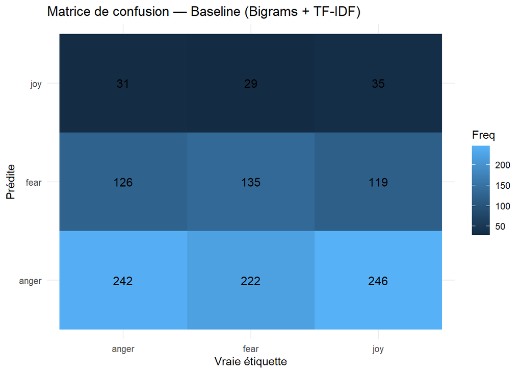

```r
conf_df <- as.data.frame(conf_baseline$table)

conf_plot <- ggplot(conf_df, aes(x = Reference, y = Prediction, fill = Freq)) +
    geom_tile() +
    geom_text(aes(label = Freq), color = "black", size = 4) +
    labs(
        title = "Matrice de confusion — Baseline (Bigrams + TF-IDF)",
        x = "Vraie étiquette",
        y = "Prédite"
    ) +
    theme_minimal()

if (!dir.exists("output/figures")) dir.create("output/figures", recursive = TRUE)
ggsave("output/figures/confusion_matrix_baseline.png", conf_plot, width = 7, height = 6)
conf_plot
```

Consistent with the previous analysis, the confusion matrix reinforces these findings by showing strong confusion between classes, especially for joy.

# Improvement 1: Raw Counts

Naive Bayes is traditionally defined on raw term frequencies. Although TF-IDF is often effective, it can reduce the influence of frequent emotion-bearing terms.

We therefore evaluate raw counts using the same unigram and bigram features for comparison.

```r
# Recreate the same tokens (uni + bi)
stopwords_emotion <- setdiff(
    stopwords::stopwords("en"),
    c("not", "no", "very", "so")
)

# Unigram tokens
tokens_uni <- data %>%
    tidytext::unnest_tokens(output = "token", input = "text_clean", token = "words", to_lower = FALSE) %>%
    filter(!token %in% stopwords_emotion) %>%
    filter(nchar(token) >= 3 | token %in% c("no", "so")) %>%
    mutate(token = textstem::lemmatize_words(token)) %>%
    mutate(token_type = "unigram")

# Bigram tokens
tokens_bi <- data %>%
    tidytext::unnest_tokens(output = "token", input = "text_clean", token = "ngrams", n = 2, to_lower = FALSE) %>%
    filter(!is.na(token)) %>%
    tidyr::separate(token, into = c("w1", "w2"), sep = " ", remove = FALSE) %>%
    filter(!(w1 %in% stopwords_emotion | w2 %in% stopwords_emotion)) %>%
    select(-w1, -w2) %>%
    mutate(token_type = "bigram")

# Combine
tokens_combined <- bind_rows(tokens_uni, tokens_bi)

# min_df/max_df filtering
min_df <- 3
max_df <- 0.80
n_docs <- n_distinct(tokens_combined$id)
max_df_count <- floor(max_df * n_docs)

doc_freq <- tokens_combined %>%
    distinct(id, token) %>%
    count(token, name = "df")

terms_to_keep <- doc_freq %>%
    filter(df >= min_df, df <= max_df_count) %>%
    pull(token)

tokens_filtered <- tokens_combined %>%
    filter(token %in% terms_to_keep)

# Create DTM with RAW COUNTS (NOT TF-IDF)
dtm_counts <- tokens_filtered %>%
    count(id, token) %>%
    tidytext::cast_dtm(document = id, term = token, value = n)

# IMPORTANT: Do NOT apply weightTfIdf() - keep raw counts


cat("Dimensions:", nrow(dtm_counts), "docs ×", ncol(dtm_counts), "features\n")
```

```
Dimensions: 5929 docs × 3173 features
```

```r
cat("Density:", round(100 * nnzero(dtm_counts) / (nrow(dtm_counts) * ncol(dtm_counts)), 2), "%\n\n")
```

```
Density: 0.28 %
```

As in the previous section, the matrix is highly sparse which is typical for text data and independent of the weighting scheme.

```r
# Split and extraction
data_counts <- align_to_dtm(dtm_counts, data)
splits_counts <- make_split(data_counts, p = 0.8, seed = 123)
feat_counts <- extract_features(dtm_counts, splits_counts$train_ids, splits_counts$test_ids)

# Train with fixed Laplace = 1
nb_counts <- e1071::naiveBayes(
    x = feat_counts$x_train,
    y = splits_counts$y_train,
    laplace = 1
)

predictions_counts <- predict(nb_counts, feat_counts$x_test)
conf_counts <- caret::confusionMatrix(predictions_counts, splits_counts$y_test)
accuracy_counts <- as.numeric(conf_counts$overall["Accuracy"])

print(conf_counts)
```

```
Confusion Matrix and Statistics

          Reference
Prediction anger fear joy
     anger   240  224 258
     fear    117  120 109
     joy      42   42  33

Overall Statistics

               Accuracy : 0.3316
                 95% CI : (0.3049, 0.3593)
    No Information Rate : 0.3376
    P-Value [Acc > NIR] : 0.6766

                  Kappa : -0.0029

 Mcnemar's Test P-Value : <2e-16

Statistics by Class:

                     Class: anger Class: fear Class: joy
Sensitivity                0.6015      0.3109    0.08250
Specificity                0.3868      0.7171    0.89299
Pos Pred Value             0.3324      0.3468    0.28205
Neg Pred Value             0.6566      0.6830    0.65637
Prevalence                 0.3367      0.3257    0.33755
Detection Rate             0.2025      0.1013    0.02785
Detection Prevalence       0.6093      0.2920    0.09873
Balanced Accuracy          0.4941      0.5140    0.48775
```

```r
comparison_tbl <- tibble::tibble(
  Model = c("Baseline (TF-IDF + Bigrams)", "Raw Counts (Bigrams)"),
  Accuracy = c(round(accuracy_baseline, 4), round(accuracy_counts, 4))
)

comparison_tbl %>%
  knitr::kable(
    caption = "Comparison of baseline and raw counts models"
  ) %>%
  kableExtra::kable_styling(
    bootstrap_options = c("striped", "condensed"),
    full_width = FALSE
  )
```

Comparison of baseline and raw counts models

| Model | Accuracy |
| --- | --- |
| Baseline (TF-IDF + Bigrams) | 0.3477 |
| Raw Counts (Bigrams) | 0.3316 |

**Confusion Matrix for Improvement 1: Raw Counts**

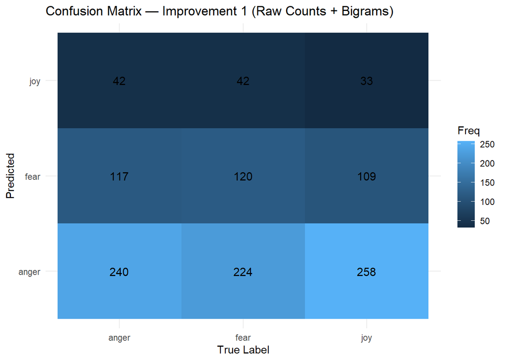

```r
conf_df_counts <- as.data.frame(conf_counts$table)

conf_plot_counts <- ggplot(conf_df_counts, aes(x = Reference, y = Prediction, fill = Freq)) +
    geom_tile() +
    geom_text(aes(label = Freq), color = "black", size = 4) +
    labs(
        title = "Confusion Matrix — Improvement 1 (Raw Counts + Bigrams)",
        x = "True Label",
        y = "Predicted"
    ) +
    theme_minimal()

conf_plot_counts
```

Using raw counts instead of TF-IDF leads to a slight decrease in performance.

This suggests that, in this setting, TF-IDF weighting remains more effective than raw term frequencies for Naive Bayes and that the poor detection of joy cannot be resolved by feature weighting alone.

# Improvement 2: Char n-grams

The baseline confusion matrix shows that joy has a very low sensitivity (≈ 9%), meaning that most joy examples are not correctly identified.

**Reason:** Positive emotions are often expressed through distinctive character-level patterns rather than fixed word combinations:

- “happ”, “excit”, “glad”, “enjoy” → joy
- “angr”, “hate”, “terr” → anger
- “scar”, “afra”, “terr” → fear

Character n-grams (n = 3–5) capture these sub-word patterns more effectively than word bigrams alone allowing the model to detect emotion-related cues that may be missed at the word level.

## Model with Char n-grams

```r
# Recreate tokens: unigrams + bigrams + character n-grams
stopwords_emotion <- setdiff(
    stopwords::stopwords("en"),
    c("not", "no", "very", "so")
)

# Unigram tokens
tokens_uni <- data %>%
    tidytext::unnest_tokens(output = "token", input = "text_clean", token = "words", to_lower = FALSE) %>%
    filter(!token %in% stopwords_emotion) %>%
    filter(nchar(token) >= 3 | token %in% c("no", "so")) %>%
    mutate(token = textstem::lemmatize_words(token)) %>%
    mutate(token_type = "unigram")

# Bigram tokens
tokens_bi <- data %>%
    tidytext::unnest_tokens(output = "token", input = "text_clean", token = "ngrams", n = 2, to_lower = FALSE) %>%
    filter(!is.na(token)) %>%
    tidyr::separate(token, into = c("w1", "w2"), sep = " ", remove = FALSE) %>%
    filter(!(w1 %in% stopwords_emotion | w2 %in% stopwords_emotion)) %>%
    select(-w1, -w2) %>%
    mutate(token_type = "bigram")

# Character n-grams (3, 4, 5) - extraire toutes les sous-chaînes
# Simple approach: loop to generate character n-grams
char_ngrams_list <- list()

for (i in 1:nrow(data)) {
    text <- data$text_clean[i]
    text_id <- data$id[i]

    # Generate char 3-grams, 4-grams, 5-grams
    for (n in 3:5) {
        if (nchar(text) >= n) {
            for (start in 1:(nchar(text) - n + 1)) {
                token <- substring(text, start, start + n - 1)
                if (nchar(token) >= 3) {
                    char_ngrams_list[[length(char_ngrams_list) + 1]] <- data.frame(
                        id = text_id,
                        token = token,
                        token_type = paste0("char_", n),
                        stringsAsFactors = FALSE )
                }
            }
        }
    }
}

char_ngrams <- do.call(rbind, char_ngrams_list)
rownames(char_ngrams) <- NULL

# Combine uni + bi + char
tokens_combined_char <- bind_rows(tokens_uni, tokens_bi, char_ngrams)

cat("Tokens unigrammes:", n_distinct(tokens_uni$token), "\n")
```

```
Tokens unigrammes: 6700
```

At the beginning, the representation relies only on unigrams resulting in a relatively compact vocabulary of 6 700 features.

```r
cat("Tokens bigrammes:", n_distinct(tokens_bi$token), "\n")
```

```
Tokens bigrammes: 16823
```

```r
cat("Tokens character n-grams:", n_distinct(char_ngrams$token), "\n")
```

```
Tokens character n-grams: 83670
```

With the introduction of character n-grams (3–5), the representation is further enriched leading to a much larger set of 83 670 sub-word features that capture fine-grained emotional patterns

```r
cat("Total features (uni + bi + char):", n_distinct(tokens_combined_char$token), "\n\n")
```

```
Total features (uni + bi + char): 104726
```

Overall, combining unigrams, bigrams and character n-grams results in a total of 104 726 features before frequency-based filtering reflecting a much richer but also more complex representation

```r
# min_df/max_df filtering
min_df <- 3
max_df <- 0.80
n_docs <- n_distinct(tokens_combined_char$id)
max_df_count <- floor(max_df * n_docs)

doc_freq_char <- tokens_combined_char %>%
    distinct(id, token) %>%
    count(token, name = "df")

terms_to_keep_char <- doc_freq_char %>%
    filter(df >= min_df, df <= max_df_count) %>%
    pull(token)

tokens_filtered_char <- tokens_combined_char %>%
    filter(token %in% terms_to_keep_char)

# Create DTM with TF-IDF (return to TF-IDF since it's more effective for joy)
dtm_char <- tokens_filtered_char %>%
    count(id, token) %>%
    tidytext::cast_dtm(document = id, term = token, value = n)

# APPLY TF-IDF
dtm_char <- tm::weightTfIdf(dtm_char)


cat("Dimensions:", nrow(dtm_char), "docs ×", ncol(dtm_char), "features\n")
```

```
Dimensions: 5931 docs × 43172 features
```

This representation results in a large feature space, but each document still activates only a small fraction of it

```r
cat("Density:", round(100 * nnzero(dtm_char) / (nrow(dtm_char) * ncol(dtm_char)), 2), "%\n\n")
```

```
Density: 0.59 %
```

As before, the matrix remains highly sparse (0.59%), which is expected for text data even with richer feature sets

```r
# Split et extraction
data_char <- align_to_dtm(dtm_char, data)
splits_char <- make_split(data_char, p = 0.8, seed = 123)
feat_char <- extract_features(dtm_char, splits_char$train_ids, splits_char$test_ids)

# Train with fixed Laplace = 1
nb_char <- e1071::naiveBayes(
    x = feat_char$x_train,
    y = splits_char$y_train,
    laplace = 1
)

predictions_char <- predict(nb_char, feat_char$x_test)
conf_char <- caret::confusionMatrix(predictions_char, splits_char$y_test)
accuracy_char <- as.numeric(conf_char$overall["Accuracy"])

print(conf_char)
```

```
Confusion Matrix and Statistics

          Reference
Prediction anger fear joy
     anger   249   76 121
     fear    114  277 122
     joy      36   33 157

Overall Statistics

               Accuracy : 0.5764
                 95% CI : (0.5477, 0.6047)
    No Information Rate : 0.3376
    P-Value [Acc > NIR] : < 2.2e-16

                  Kappa : 0.3657

 Mcnemar's Test P-Value : < 2.2e-16

Statistics by Class:

                     Class: anger Class: fear Class: joy
Sensitivity                0.6241      0.7176     0.3925
Specificity                0.7494      0.7046     0.9121
Pos Pred Value             0.5583      0.5400     0.6947
Neg Pred Value             0.7970      0.8378     0.7466
Prevalence                 0.3367      0.3257     0.3376
Detection Rate             0.2101      0.2338     0.1325
Detection Prevalence       0.3764      0.4329     0.1907
Balanced Accuracy          0.6867      0.7111     0.6523
```

**Confusion Matrix for Improvement 2: Character n-grams**

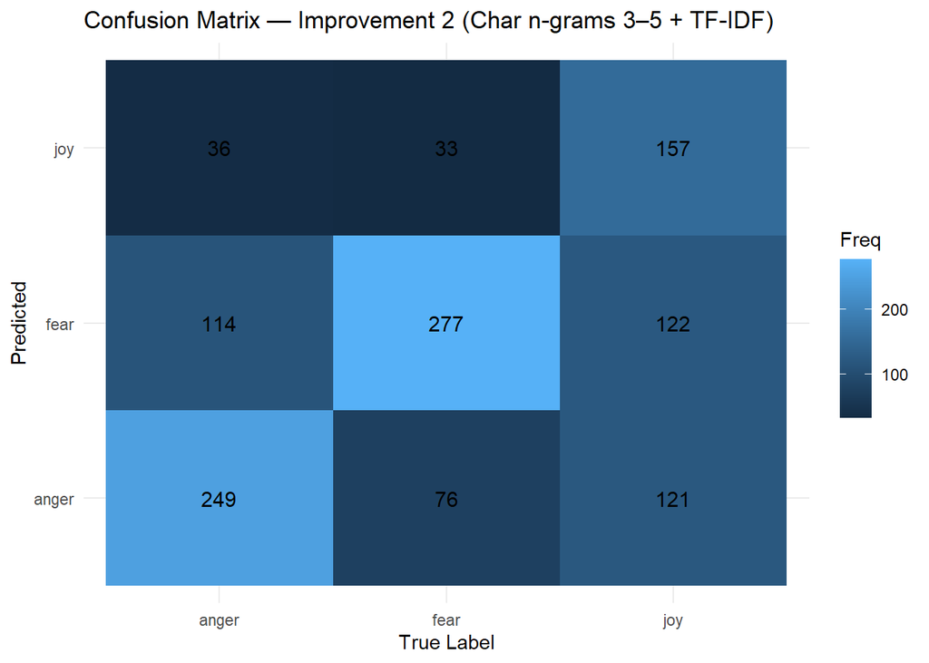

```r
conf_df_char <- as.data.frame(conf_char$table)

conf_plot_char <- ggplot(conf_df_char, aes(x = Reference, y = Prediction, fill = Freq)) +
    geom_tile() +
    geom_text(aes(label = Freq), color = "black", size = 4) +
    labs(
        title = "Confusion Matrix — Improvement 2 (Char n-grams 3–5 + TF-IDF)",
        x = "True Label",
        y = "Predicted"
    ) +
    theme_minimal()

conf_plot_char
```

```r
comparison_char_tbl <- tibble::tibble(
  Model = c("Baseline (TF-IDF + Bigrams)",
            "Character n-grams (3–5 + TF-IDF)"),
  Accuracy = c(round(accuracy_baseline, 4),
               round(accuracy_char, 4))
)

comparison_char_tbl %>%
  knitr::kable(
    caption = "Comparison between baseline and character n-gram model"
  ) %>%
  kableExtra::kable_styling(
    bootstrap_options = c("striped", "condensed"),
    full_width = FALSE
  )
```

Comparison between baseline and character n-gram model

| Model | Accuracy |
| --- | --- |
| Baseline (TF-IDF + Bigrams) | 0.3477 |
| Character n-grams (3–5 + TF-IDF) | 0.5764 |

The introduction of character n-grams results in a large and consistent performance gain compared to the baseline with an accuracy increase of more than 20 percentage points.

This improvement confirms that capturing sub-word patterns provides valuable emotional cues that are largely missed by word-based representations, especially for joy which was poorly detected in the baseline model.

```r
# Comparison of sensitivities across all three models
sensitivity_comparison <- tibble::tibble(
  Emotion = c("anger", "fear", "joy"),
  Baseline = c(
    conf_baseline$byClass["Class: anger", "Sensitivity"],
    conf_baseline$byClass["Class: fear", "Sensitivity"],
    conf_baseline$byClass["Class: joy", "Sensitivity"]
  ),
  `Improvement 1 (Raw Counts)` = c(
    conf_counts$byClass["Class: anger", "Sensitivity"],
    conf_counts$byClass["Class: fear", "Sensitivity"],
    conf_counts$byClass["Class: joy", "Sensitivity"]
  ),
  `Improvement 2 (Char n-grams)` = c(
    conf_char$byClass["Class: anger", "Sensitivity"],
    conf_char$byClass["Class: fear", "Sensitivity"],
    conf_char$byClass["Class: joy", "Sensitivity"]
  )
) %>%
  mutate(
    across(c(Baseline, `Improvement 1 (Raw Counts)`, `Improvement 2 (Char n-grams)`),
           ~ round(.x, 4))
  )

sensitivity_comparison %>%
  knitr::kable(
    caption = "Sensitivity comparison across baseline and improvements"
  ) %>%
  kableExtra::kable_styling(
    bootstrap_options = c("striped", "condensed"),
    full_width = FALSE
  )
```

Sensitivity comparison across baseline and improvements

| Emotion | Baseline | Improvement 1 (Raw Counts) | Improvement 2 (Char n-grams) |
| --- | --- | --- | --- |
| anger | 0.6065 | 0.6015 | 0.6241 |
| fear | 0.3497 | 0.3109 | 0.7176 |
| joy | 0.0875 | 0.0825 | 0.3925 |

This table clearly shows that the character n-gram model substantially improves the detection of joy while also leading to a strong gain for fear. These results confirm that sub-word patterns capture meaningful emotional signals that are missed by word-based representations.

# Improvement 3: Differential filtering + bigram reinforcement + Class prior adjustment

We apply three lightweight optimizations:

1. **Differential feature filtering:** stricter filtering for char n-grams (min_df = 5) instead unigrams/bigrams (min_df = 3)
2. **Bigram reinforcement:** double bigram tokens to give them more weight
3. **Class prior adjustment:** increase joy prior by 25% to address under-detection

```r
# Recreate tokens: unigrams + bigrams + character n-grams
stopwords_emotion <- setdiff(
    stopwords::stopwords("en"),
    c("not", "no", "very", "so")
)

# Unigram tokens
tokens_uni <- data %>%
    tidytext::unnest_tokens(output = "token", input = "text_clean", token = "words", to_lower = FALSE) %>%
    filter(!token %in% stopwords_emotion) %>%
    filter(nchar(token) >= 3 | token %in% c("no", "so")) %>%
    mutate(token = textstem::lemmatize_words(token)) %>%
    mutate(token_type = "unigram")

# Bigram tokens
tokens_bi <- data %>%
    tidytext::unnest_tokens(output = "token", input = "text_clean", token = "ngrams", n = 2, to_lower = FALSE) %>%
    filter(!is.na(token)) %>%
    tidyr::separate(token, into = c("w1", "w2"), sep = " ", remove = FALSE) %>%
    filter(!(w1 %in% stopwords_emotion | w2 %in% stopwords_emotion)) %>%
    select(-w1, -w2) %>%
    mutate(token_type = "bigram")

# Character n-grams (3, 4, 5)
char_ngrams_list <- list()
for (i in 1:nrow(data)) {
    text <- data$text_clean[i]
    text_id <- data$id[i]
    for (n in 3:5) {
        if (nchar(text) >= n) {
            for (start in 1:(nchar(text) - n + 1)) {
                token <- substring(text, start, start + n - 1)
                if (nchar(token) >= 3) {
                    char_ngrams_list[[length(char_ngrams_list) + 1]] <- data.frame(
                        id = text_id,
                        token = token,
                        token_type = paste0("char_", n),
                        stringsAsFactors = FALSE
                    )
                }
            }
        }
    }
}
char_ngrams <- do.call(rbind, char_ngrams_list)
rownames(char_ngrams) <- NULL

# Combine all tokens
tokens_combined_tuned <- bind_rows(tokens_uni, tokens_bi, char_ngrams)
```

**Step 1: Differential filtering**

Apply stricter filtering to character n-grams (min_df = 5) while keeping unigrams and bigrams at min_df = 3:

```r
# Compute document frequency by token type
doc_freq_all <- tokens_combined_tuned %>%
    distinct(id, token, token_type) %>%
    count(token, token_type, name = "df")

n_docs_tuned <- n_distinct(tokens_combined_tuned$id)
max_df_count <- floor(0.80 * n_docs_tuned)

# Apply differential min_df
terms_to_keep_tuned <- doc_freq_all %>%
    filter(
        (token_type %in% c("char_3", "char_4", "char_5") & df >= 5 & df <= max_df_count) |
        (token_type %in% c("unigram", "bigram") & df >= 3 & df <= max_df_count)
    ) %>%
    pull(token)

tokens_filtered_tuned <- tokens_combined_tuned %>%
    filter(token %in% terms_to_keep_tuned)
```

**Step 2: Bigram reinforcement**

Duplicate bigrams to give them extra weight:

```r
# Duplicate bigrams for reinforcement
tokens_reinforced <- bind_rows(
    tokens_filtered_tuned,
    tokens_filtered_tuned %>% filter(token_type == "bigram")
)

cat("  Unigrams:", n_distinct(tokens_reinforced %>% filter(token_type == "unigram") %>% pull(token)), "\n")
```

```
  Unigrams: 2501
```

```r
cat("  Bigrams:", n_distinct(tokens_reinforced %>% filter(token_type == "bigram") %>% pull(token)), "\n")
```

```
  Bigrams: 1036
```

```r
cat("  Char n-grams:", n_distinct(tokens_reinforced %>% filter(grepl("char_", token_type)) %>% pull(token)), "\n\n")
```

```
  Char n-grams: 30429
```

**Step 3: Train model with class prior adjustment**

```r
# Create DTM with TF-IDF
dtm_tuned <- tokens_reinforced %>%
    count(id, token) %>%
    tidytext::cast_dtm(document = id, term = token, value = n)

dtm_tuned <- tm::weightTfIdf(dtm_tuned)

cat("DTM dimensions:", nrow(dtm_tuned), "docs ×", ncol(dtm_tuned), "features\n\n")
```

```
DTM dimensions: 5931 docs × 32606 features
```

```r
# Split
data_tuned <- align_to_dtm(dtm_tuned, data)
splits_tuned <- make_split(data_tuned, p = 0.8, seed = 123)
feat_tuned <- extract_features(dtm_tuned, splits_tuned$train_ids, splits_tuned$test_ids)

# Compute adjusted priors (increase joy by 25%)
raw_priors <- table(splits_tuned$y_train) / length(splits_tuned$y_train)
adjusted_priors <- raw_priors

joy_idx <- which(names(adjusted_priors) == "joy")
if (length(joy_idx) > 0) {
    adjusted_priors[joy_idx] <- adjusted_priors[joy_idx] * 1.25
    adjusted_priors <- adjusted_priors / sum(adjusted_priors)
}

# Train with Laplace = 1 and adjust priors
nb_tuned <- e1071::naiveBayes(
    x = feat_tuned$x_train,
    y = splits_tuned$y_train,
    laplace = 1
)

# Override priors
nb_tuned$apriori <- adjusted_priors

# Predict
predictions_tuned <- predict(nb_tuned, feat_tuned$x_test)
conf_tuned <- caret::confusionMatrix(predictions_tuned, splits_tuned$y_test)
accuracy_tuned <- as.numeric(conf_tuned$overall["Accuracy"])

print(conf_tuned)
```

```
Confusion Matrix and Statistics

          Reference
Prediction anger fear joy
     anger   242   64 103
     fear    118  286 129
     joy      39   36 168

Overall Statistics

               Accuracy : 0.5873
                 95% CI : (0.5587, 0.6155)
    No Information Rate : 0.3376
    P-Value [Acc > NIR] : < 2.2e-16

                  Kappa : 0.3823

 Mcnemar's Test P-Value : < 2.2e-16

Statistics by Class:

                     Class: anger Class: fear Class: joy
Sensitivity                0.6065      0.7409     0.4200
Specificity                0.7875      0.6909     0.9045
Pos Pred Value             0.5917      0.5366     0.6914
Neg Pred Value             0.7977      0.8466     0.7537
Prevalence                 0.3367      0.3257     0.3376
Detection Rate             0.2042      0.2414     0.1418
Detection Prevalence       0.3451      0.4498     0.2051
Balanced Accuracy          0.6970      0.7159     0.6622
```

**Confusion Matrix for Improvement 3: Optimized Model**

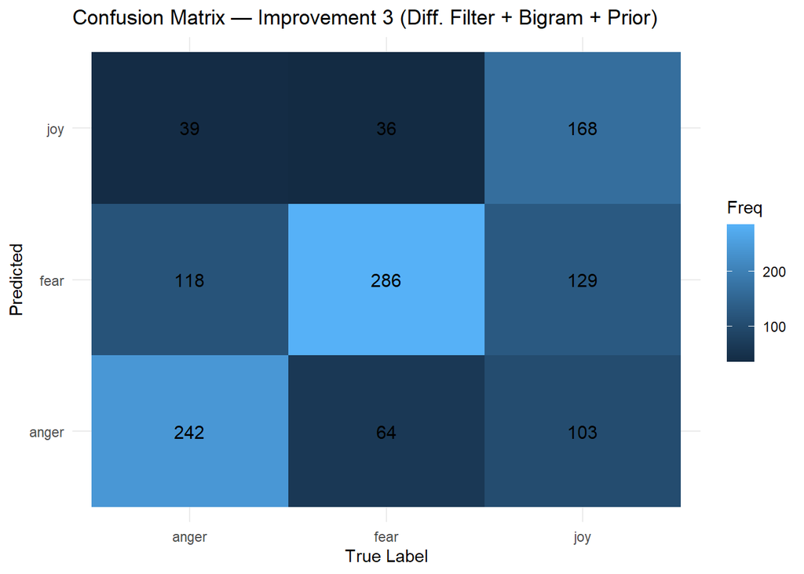

```r
conf_df_tuned <- as.data.frame(conf_tuned$table)

conf_plot_tuned <- ggplot(conf_df_tuned, aes(x = Reference, y = Prediction, fill = Freq)) +
    geom_tile() +
    geom_text(aes(label = Freq), color = "black", size = 4) +
    labs(
        title = "Confusion Matrix — Improvement 3 (Diff. Filter + Bigram + Prior)",
        x = "True Label",
        y = "Predicted"
    ) +
    theme_minimal()

conf_plot_tuned
```

```r
accuracy_summary <- tibble::tibble(
    Model = c("Baseline (TF-IDF + Bigrams)",
              "Char n-grams",
              "Optimized (Diff. Filter + Bigram + Prior)"),
    Accuracy = c(round(accuracy_baseline, 4),
                 round(accuracy_char, 4),
                 round(accuracy_tuned, 4))
)

accuracy_summary %>%
  knitr::kable(caption = "Final accuracy comparison") %>%
  kableExtra::kable_styling(bootstrap_options = c("striped", "condensed"), full_width = FALSE)
```

Final accuracy comparison

| Model | Accuracy |
| --- | --- |
| Baseline (TF-IDF + Bigrams) | 0.3477 |
| Char n-grams | 0.5764 |
| Optimized (Diff. Filter + Bigram + Prior) | 0.5873 |

The optimized configuration provides a modest but consistent improvement over the character n-gram model, increasing a little bit the accuracy . While most of the performance gain comes from the introduction of character n-grams, the additional tuning steps slightly improve class balance and refine the decision boundaries without increasing model complexity.

# Conclusion

In this project, we explored emotion classification from text using a Naive Bayes model with a particular focus on how feature representation influences performance. A key challenge was the poor detection of joy which the initial word-based baseline struggled to capture. Early experiments using raw term counts showed that changing the weighting scheme alone was not sufficient to substantially improve results.

Although the final model remains constrained by the independence assumptions of Naive Bayes, the results demonstrate that careful feature engineering and controlled tuning can substantially enhance performance even with relatively simple classifiers. Overall, this work highlights the central role of representation design in emotion classification tasks.